# Spatio-temporal disease mapping with `R-INLA`

Julien Riou

2024-03-07

# 1 Temporal models in `R-INLA`

Now we change the focus from space to time, focusing on weekly cases at the national level.

```r
flu_week_ch = flu %>%
  filter(georegion=="CHFL", agegroup=="all", sex=="all", type=="all") %>%
  mutate(week_of_season=lag(week_of_year,flu_season_start_week),
         week_of_season=ifelse(is.na(week_of_season),lead(week_of_season,52),week_of_season))
```

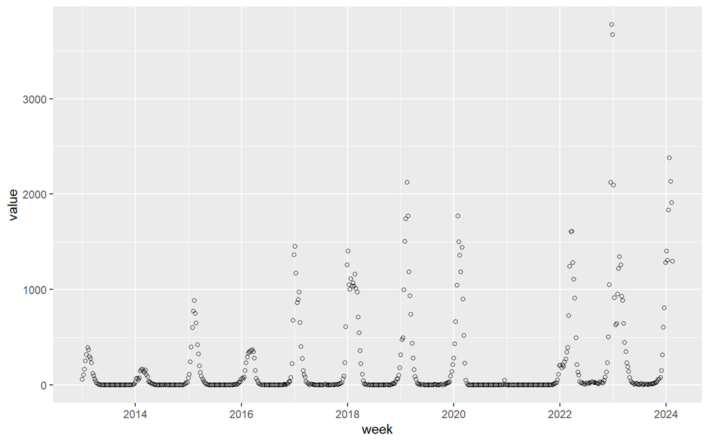

```r
ggplot(flu_week_ch,aes(x=week,y=value)) +
  geom_point(shape=21)
```

## 1.1 Random walks

### 1.1.1 `rw1` model

The first approach we can try to model a time series is a random walk, which is a special type of random effect. A random walk of order 1 (`rw1`) assumes that every increment from one time point to the next $\Delta y_t = y_t - y_{t-1}$ follows a normal distribution. It is discrete by definition, so it is well suited to regular time series (data by day or week or month). There are also continuous versions.

```r
m_week1 = inla(value ~ 1 +
                 f(week_index, model="rw1", hyper=list(prec=list(param=c(1, 0.1))), constr=TRUE),
               offset = log(pop),
               data=flu_week_ch,
               family = "poisson",
               control.fixed = list(mean.intercept=0, prec.intercept=1/10^2),
               control.compute = list(waic=TRUE))
summary(m_week1)
```

```
##
## Call:
##    c("inla.core(formula = formula, family = family, contrasts = contrasts,
##    ", " data = data, quantiles = quantiles, E = E, offset = offset, ", "
##    scale = scale, weights = weights, Ntrials = Ntrials, strata = strata,
##    ", " lp.scale = lp.scale, link.covariates = link.covariates, verbose =
##    verbose, ", " lincomb = lincomb, selection = selection, control.compute
##    = control.compute, ", " control.predictor = control.predictor,
##    control.family = control.family, ", " control.inla = control.inla,
##    control.fixed = control.fixed, ", " control.mode = control.mode,
##    control.expert = control.expert, ", " control.hazard = control.hazard,
##    control.lincomb = control.lincomb, ", " control.update =
##    control.update, control.lp.scale = control.lp.scale, ", "
##    control.pardiso = control.pardiso, only.hyperparam = only.hyperparam,
##    ", " inla.call = inla.call, inla.arg = inla.arg, num.threads =
##    num.threads, ", " keep = keep, working.directory = working.directory,
##    silent = silent, ", " inla.mode = inla.mode, safe = FALSE, debug =
##    debug, .parent.frame = .parent.frame)" )
## Time used:
##     Pre = 3.03, Running = 0.962, Post = 0.27, Total = 4.26
## Fixed effects:
##               mean   sd 0.025quant 0.5quant 0.975quant    mode kld
## (Intercept) -13.41 0.03    -13.469  -13.409    -13.351 -13.409   0
##
## Random effects:
##   Name     Model
##     week_index RW1 model
##
## Model hyperparameters:
##                          mean    sd 0.025quant 0.5quant 0.975quant mode
## Precision for week_index 3.65 0.298       3.09     3.64       4.26 3.63
##
## Watanabe-Akaike information criterion (WAIC) ...: 3356.05
## Effective number of parameters .................: 206.15
##
## Marginal log-Likelihood:  -2186.74
##  is computed
## Posterior summaries for the linear predictor and the fitted values are computed
## (Posterior marginals needs also 'control.compute=list(return.marginals.predictor=TRUE)')
```

We can look at the model fit to get a sense of how it works.

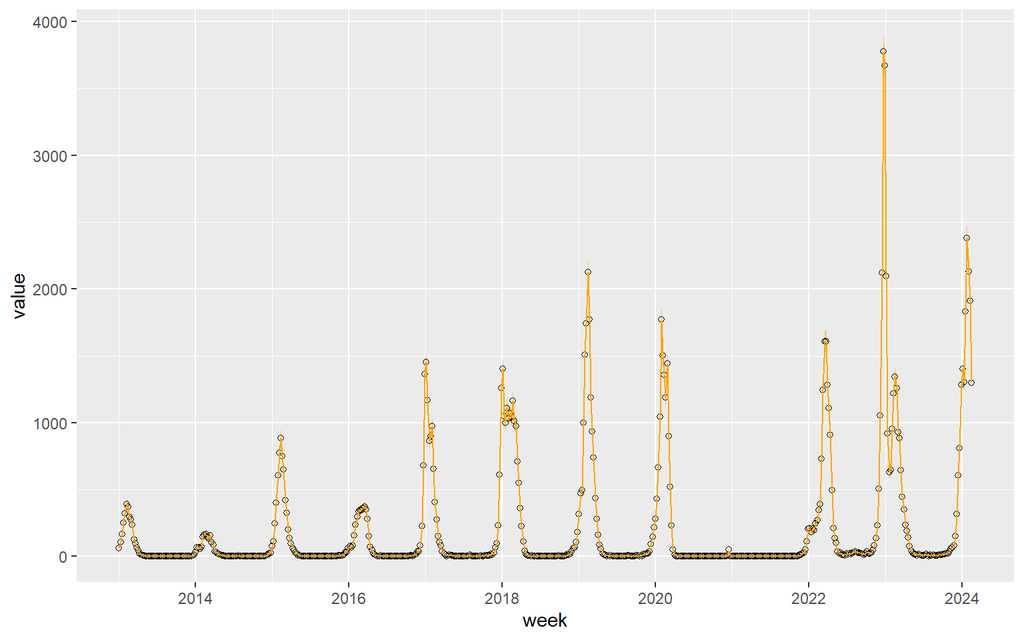

```r
m_week1$summary.fitted.values %>%
  bind_cols(flu_week_ch) %>%
  ggplot(aes(x=week)) +
  geom_ribbon(aes(ymin=`0.025quant`,ymax=`0.975quant`),fill="orange",alpha=.5) +
  geom_point(aes(y=value),shape=21)  +
  geom_line(aes(y=mean),colour="orange")
```

Let us zoom at one particular epidemic season.

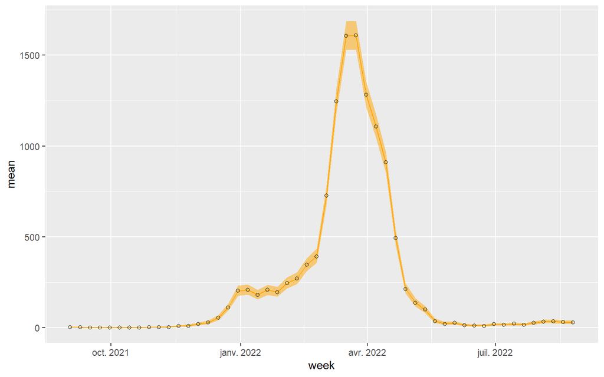

```r
m_week1$summary.fitted.values %>%
  bind_cols(flu_week_ch) %>%
  filter(season=="2021-2022") %>%
  ggplot(aes(x=week)) +
  geom_ribbon(aes(ymin=`0.025quant`,ymax=`0.975quant`),fill="orange",alpha=.5)  +
  geom_line(aes(y=mean),colour="orange") +
  geom_point(aes(y=value),shape=21)
```

The model seems to fit the data quite well. Actually, maybe too well! The predictions from the model follow every change, and the uncertainty intervals are narrow, which indicates some degree of **overfitting**. Still, it might not be a problem as the data is not particularly wiggly. This problem often occurs when using Poisson regression in time series. It comes from the large variations across time, and the fact that the variance doesn’t scale well for small and large counts. We can try the “overdispersed” version of Poisson regression, negative binomial regression.

```r
m_week2 = inla(value ~ 1 +
                 f(week_index, model="rw1", hyper=list(prec=list(param=c(1, 0.1))), constr=TRUE),
               offset = log(pop),
               data=flu_week_ch,
               family = "nbinomial",
               control.fixed = list(mean.intercept=0, prec.intercept=1/10^2),
               control.compute = list(waic=TRUE))
summary(m_week2)
```

```
##
## Call:
##    c("inla.core(formula = formula, family = family, contrasts = contrasts,
##    ", " data = data, quantiles = quantiles, E = E, offset = offset, ", "
##    scale = scale, weights = weights, Ntrials = Ntrials, strata = strata,
##    ", " lp.scale = lp.scale, link.covariates = link.covariates, verbose =
##    verbose, ", " lincomb = lincomb, selection = selection, control.compute
##    = control.compute, ", " control.predictor = control.predictor,
##    control.family = control.family, ", " control.inla = control.inla,
##    control.fixed = control.fixed, ", " control.mode = control.mode,
##    control.expert = control.expert, ", " control.hazard = control.hazard,
##    control.lincomb = control.lincomb, ", " control.update =
##    control.update, control.lp.scale = control.lp.scale, ", "
##    control.pardiso = control.pardiso, only.hyperparam = only.hyperparam,
##    ", " inla.call = inla.call, inla.arg = inla.arg, num.threads =
##    num.threads, ", " keep = keep, working.directory = working.directory,
##    silent = silent, ", " inla.mode = inla.mode, safe = FALSE, debug =
##    debug, .parent.frame = .parent.frame)" )
## Time used:
##     Pre = 2.55, Running = 1.49, Post = 0.333, Total = 4.38
## Fixed effects:
##                mean   sd 0.025quant 0.5quant 0.975quant    mode kld
## (Intercept) -13.409 0.03    -13.468  -13.409     -13.35 -13.409   0
##
## Random effects:
##   Name     Model
##     week_index RW1 model
##
## Model hyperparameters:
##                                                            mean       sd
## size for the nbinomial observations (1/overdispersion) 44077.25 4.11e+05
## Precision for week_index                                   3.64 2.98e-01
##                                                        0.025quant 0.5quant
## size for the nbinomial observations (1/overdispersion)     178.65  3775.92
## Precision for week_index                                     3.07     3.64
##                                                        0.975quant   mode
## size for the nbinomial observations (1/overdispersion)   2.85e+05 353.95
## Precision for week_index                                 4.24e+00   3.65
##
## Watanabe-Akaike information criterion (WAIC) ...: 3419.88
## Effective number of parameters .................: 208.91
##
## Marginal log-Likelihood:  -2188.28
##  is computed
## Posterior summaries for the linear predictor and the fitted values are computed
## (Posterior marginals needs also 'control.compute=list(return.marginals.predictor=TRUE)')
```

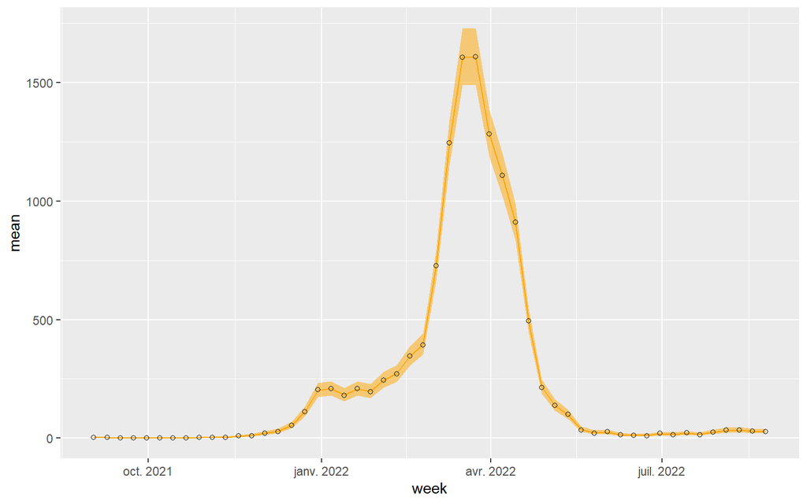

```r
m_week2$summary.fitted.values %>%
  bind_cols(flu_week_ch) %>%
  filter(season=="2021-2022") %>%
  ggplot(aes(x=week)) +
  geom_ribbon(aes(ymin=`0.025quant`,ymax=`0.975quant`),fill="orange",alpha=.5)  +
  geom_line(aes(y=mean),colour="orange") +
  geom_point(aes(y=value),shape=21)
```

The difference is not that striking. Uncertainty intervals are slightly larger. We can look at the WAIC to compare the two versions.

```r
m_week1$waic$waic
```

```
## [1] 3356.049
```

```r
m_week2$waic$waic
```

```
## [1] 3419.875
```

The WAIC is actually lower for Poisson than for negative binomial, so we continue with the former. But in many situations (especially when there is a lot of variation), the negative binomial model will probably be better.

The next thing we want to try is a **second order random walk**. It follows the same principle as first order random walk, but takes into account the increment over the last two observations rather than only the last one. The advantage is that it can provide more smoothing and not follow every deviation.

```r
m_week3 = inla(value ~ 1 +
                 f(week_index, model="rw2", hyper=list(prec = list(param = c(1, 0.1)))),
               offset = log(pop),
               data=flu_week_ch,
               family = "poisson",
               control.fixed = list(mean.intercept=0, prec.intercept=1/10^2),
               control.compute = list(waic=TRUE))
summary(m_week3)
```

```
##
## Call:
##    c("inla.core(formula = formula, family = family, contrasts = contrasts,
##    ", " data = data, quantiles = quantiles, E = E, offset = offset, ", "
##    scale = scale, weights = weights, Ntrials = Ntrials, strata = strata,
##    ", " lp.scale = lp.scale, link.covariates = link.covariates, verbose =
##    verbose, ", " lincomb = lincomb, selection = selection, control.compute
##    = control.compute, ", " control.predictor = control.predictor,
##    control.family = control.family, ", " control.inla = control.inla,
##    control.fixed = control.fixed, ", " control.mode = control.mode,
##    control.expert = control.expert, ", " control.hazard = control.hazard,
##    control.lincomb = control.lincomb, ", " control.update =
##    control.update, control.lp.scale = control.lp.scale, ", "
##    control.pardiso = control.pardiso, only.hyperparam = only.hyperparam,
##    ", " inla.call = inla.call, inla.arg = inla.arg, num.threads =
##    num.threads, ", " keep = keep, working.directory = working.directory,
##    silent = silent, ", " inla.mode = inla.mode, safe = FALSE, debug =
##    debug, .parent.frame = .parent.frame)" )
## Time used:
##     Pre = 2.57, Running = 1.24, Post = 0.314, Total = 4.12
## Fixed effects:
##                mean    sd 0.025quant 0.5quant 0.975quant    mode kld
## (Intercept) -13.429 0.032    -13.491  -13.429    -13.366 -13.429   0
##
## Random effects:
##   Name     Model
##     week_index RW2 model
##
## Model hyperparameters:
##                           mean   sd 0.025quant 0.5quant 0.975quant  mode
## Precision for week_index 17.03 1.85      13.65    16.95      20.89 16.79
##
## Watanabe-Akaike information criterion (WAIC) ...: 3459.51
## Effective number of parameters .................: 208.23
##
## Marginal log-Likelihood:  -2113.16
##  is computed
## Posterior summaries for the linear predictor and the fitted values are computed
## (Posterior marginals needs also 'control.compute=list(return.marginals.predictor=TRUE)')
```

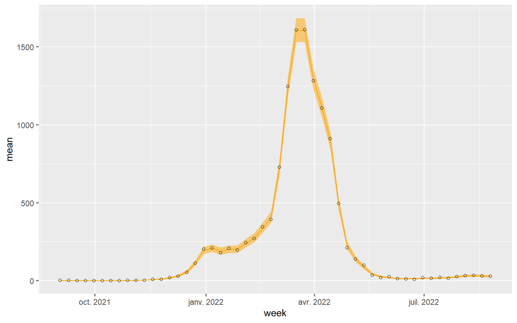

```r
m_week3$summary.fitted.values %>%
  bind_cols(flu_week_ch) %>%
  filter(season=="2021-2022") %>%
  ggplot(aes(x=week)) +
  geom_ribbon(aes(ymin=`0.025quant`,ymax=`0.975quant`),fill="orange",alpha=.5)  +
  geom_line(aes(y=mean),colour="orange") +
  geom_point(aes(y=value),shape=21)
```

```r
m_week1$waic$waic
```

```
## [1] 3356.049
```

```r
m_week3$waic$waic
```

```
## [1] 3459.509
```

Again, the difference is not striking, and the WAIC is worse, so that it does not seems to be helpful in this case. It’s also possible to control the level of smoothness by using more constrained priors, for instance penalized complexity priors (`hyper=list(prec = list(prior="pc.prior",param = c(1, 0.1)))`).

## 1.2 Autoregressive

Autoregressive random effects are another class of models useable in this situation, that behave slightly differently. For first order autoregressive models (`ar1`), the value on time $t$ depends on the value on time $t-1$ and a correlation coefficient $\rho$. It results in generally smoother estimates than `rw1`. Autoregressive models of higher order consider more past observations (up to 10). It is slightly more complicated to implement (see `inla.doc("^ar$")`).

```r
m_week4 = inla(value ~ 1 +
                 f(week_index, model="ar1", hyper=list(prec=list(param=c(1, 0.1))), constr=TRUE),
               offset = log(pop),
               data=flu_week_ch,
               family = "poisson",
               control.fixed = list(mean.intercept=0, prec.intercept=1/10^2),
               control.compute = list(waic=TRUE))
summary(m_week4)
```

```
##
## Call:
##    c("inla.core(formula = formula, family = family, contrasts = contrasts,
##    ", " data = data, quantiles = quantiles, E = E, offset = offset, ", "
##    scale = scale, weights = weights, Ntrials = Ntrials, strata = strata,
##    ", " lp.scale = lp.scale, link.covariates = link.covariates, verbose =
##    verbose, ", " lincomb = lincomb, selection = selection, control.compute
##    = control.compute, ", " control.predictor = control.predictor,
##    control.family = control.family, ", " control.inla = control.inla,
##    control.fixed = control.fixed, ", " control.mode = control.mode,
##    control.expert = control.expert, ", " control.hazard = control.hazard,
##    control.lincomb = control.lincomb, ", " control.update =
##    control.update, control.lp.scale = control.lp.scale, ", "
##    control.pardiso = control.pardiso, only.hyperparam = only.hyperparam,
##    ", " inla.call = inla.call, inla.arg = inla.arg, num.threads =
##    num.threads, ", " keep = keep, working.directory = working.directory,
##    silent = silent, ", " inla.mode = inla.mode, safe = FALSE, debug =
##    debug, .parent.frame = .parent.frame)" )
## Time used:
##     Pre = 2.79, Running = 1.52, Post = 0.321, Total = 4.64
## Fixed effects:
##                mean   sd 0.025quant 0.5quant 0.975quant    mode kld
## (Intercept) -13.406 0.03    -13.465  -13.406    -13.348 -13.406   0
##
## Random effects:
##   Name     Model
##     week_index AR1 model
##
## Model hyperparameters:
##                           mean    sd 0.025quant 0.5quant 0.975quant  mode
## Precision for week_index 0.151 0.045      0.067    0.150      0.236 0.149
## Rho for week_index       0.979 0.006      0.968    0.979      0.991 0.979
##
## Watanabe-Akaike information criterion (WAIC) ...: 3355.82
## Effective number of parameters .................: 206.16
##
## Marginal log-Likelihood:  -2193.23
##  is computed
## Posterior summaries for the linear predictor and the fitted values are computed
## (Posterior marginals needs also 'control.compute=list(return.marginals.predictor=TRUE)')
```

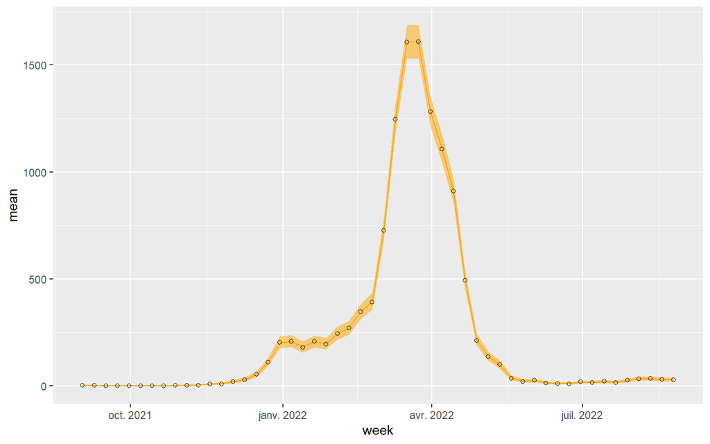

```r
m_week4$summary.fitted.values %>%
  bind_cols(flu_week_ch) %>%
  filter(season=="2021-2022") %>%
  ggplot(aes(x=week)) +
  geom_ribbon(aes(ymin=`0.025quant`,ymax=`0.975quant`),fill="orange",alpha=.5)  +
  geom_line(aes(y=mean),colour="orange") +
  geom_point(aes(y=value),shape=21)
```

```r
m_week1$waic$waic
```

```
## [1] 3356.049
```

```r
m_week4$waic$waic
```

```
## [1] 3355.821
```

In this case it doesn’t really make a difference, but it still good to keep in mind.

## 1.3 Seasonality

It is possible to add multiple components in order to disentangle between effects over different scales. For instance, we can decompose the time series of influenza into two components: a seasonal effect based on the week of the year and a residual effect capturing deviations from the average.

```r
flu_week_ch2 = flu_week_ch %>% filter(week_of_year!=53) # best to remove the 53rd week as it messes with the seasonality
m_week4 = inla(value ~ 1 +
                 f(week_index, model="rw1", hyper=list(prec=list(param=c(1, 0.1))), constr=TRUE) +
                 f(week_of_year, model="rw1", hyper=list(prec=list(param=c(1, 0.1))), constr = TRUE),
               offset = log(pop),
               data=flu_week_ch2,
               family = "poisson",
               control.fixed = list(mean.intercept=0, prec.intercept=1/10^2),
               control.compute = list(waic=TRUE))
summary(m_week4)
```

```
##
## Call:
##    c("inla.core(formula = formula, family = family, contrasts = contrasts,
##    ", " data = data, quantiles = quantiles, E = E, offset = offset, ", "
##    scale = scale, weights = weights, Ntrials = Ntrials, strata = strata,
##    ", " lp.scale = lp.scale, link.covariates = link.covariates, verbose =
##    verbose, ", " lincomb = lincomb, selection = selection, control.compute
##    = control.compute, ", " control.predictor = control.predictor,
##    control.family = control.family, ", " control.inla = control.inla,
##    control.fixed = control.fixed, ", " control.mode = control.mode,
##    control.expert = control.expert, ", " control.hazard = control.hazard,
##    control.lincomb = control.lincomb, ", " control.update =
##    control.update, control.lp.scale = control.lp.scale, ", "
##    control.pardiso = control.pardiso, only.hyperparam = only.hyperparam,
##    ", " inla.call = inla.call, inla.arg = inla.arg, num.threads =
##    num.threads, ", " keep = keep, working.directory = working.directory,
##    silent = silent, ", " inla.mode = inla.mode, safe = FALSE, debug =
##    debug, .parent.frame = .parent.frame)" )
## Time used:
##     Pre = 2.81, Running = 1.46, Post = 0.354, Total = 4.62
## Fixed effects:
##                mean    sd 0.025quant 0.5quant 0.975quant    mode kld
## (Intercept) -13.446 0.031    -13.507  -13.446    -13.386 -13.446   0
##
## Random effects:
##   Name     Model
##     week_index RW1 model
##    week_of_year RW1 model
##
## Model hyperparameters:
##                            mean    sd 0.025quant 0.5quant 0.975quant mode
## Precision for week_index   9.53 0.958       7.79     9.48      11.56 9.39
## Precision for week_of_year 8.95 2.056       5.53     8.74      13.57 8.37
##
## Watanabe-Akaike information criterion (WAIC) ...: 3380.21
## Effective number of parameters .................: 201.04
##
## Marginal log-Likelihood:  -2095.59
##  is computed
## Posterior summaries for the linear predictor and the fitted values are computed
## (Posterior marginals needs also 'control.compute=list(return.marginals.predictor=TRUE)')
```

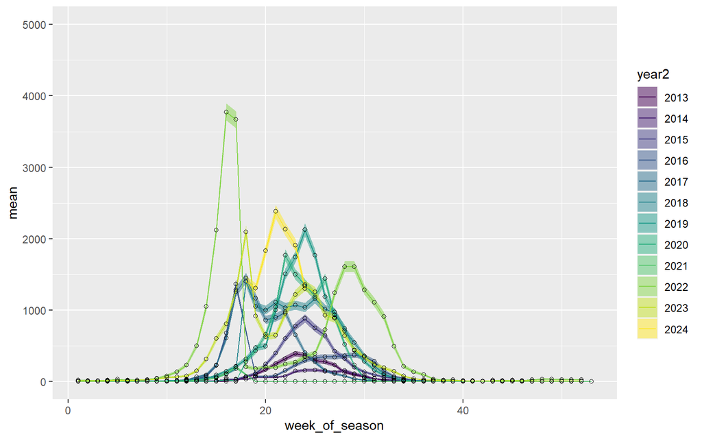

```r
m_week4$summary.fitted.values %>%
  bind_cols(flu_week_ch2) %>%
  ggplot(aes(x=week_of_season)) +
  geom_ribbon(aes(ymin=`0.025quant`,ymax=`0.975quant`,fill=year2),alpha=.5)  +
  geom_line(aes(y=mean,,colour=year2)) +
  geom_point(aes(y=value),shape=21) +
  scale_fill_viridis_d() + scale_colour_viridis_d() + coord_cartesian(ylim=c(0,5000))
```

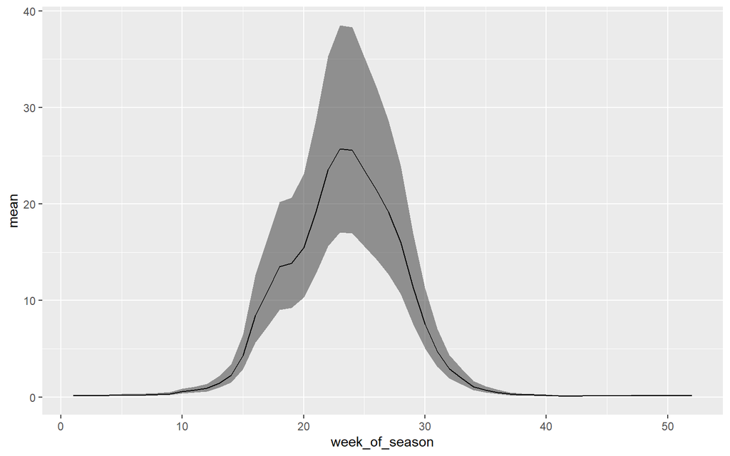

```r
m_week4$summary.random$week_of_year %>%
  select(week_of_year=ID,mean,`0.025quant`,`0.975quant`) %>%
  mutate(across(2:4,exp)) %>%
  left_join(flu_week_ch2 %>% filter(year==2023) %>% select(week_of_year,week_of_season) %>% distinct(),by = join_by(week_of_year)) %>%
  ggplot(aes(x=week_of_season)) +
  geom_ribbon(aes(ymin=`0.025quant`,ymax=`0.975quant`),alpha=.5)  +
  geom_line(aes(y=mean))
```

This seasonal effect can be interpreted as the average profile of influenza reports over the year. Note that this effect is multiplicative (because of the $\log$) and applies to the other effects times the population. It is also centered around zero (1 after exponentiation).

From this average shape there can be deviations which are captures by the other `rw1` component.

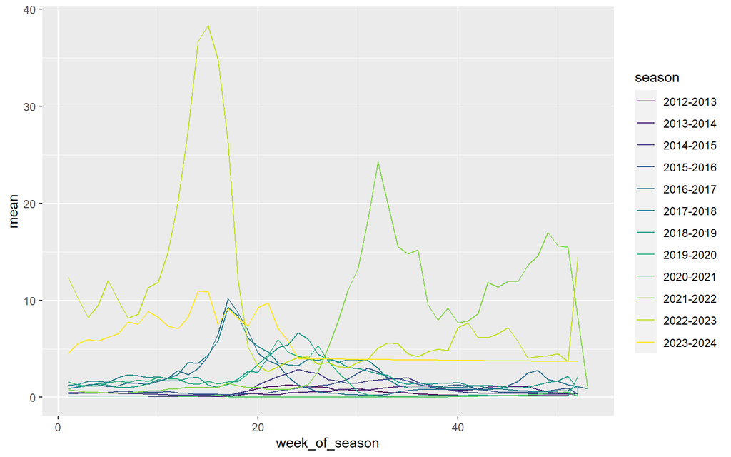

```r
m_week4$summary.random$week_index %>%
  select(week_index=ID,mean,`0.025quant`,`0.975quant`) %>%
  mutate(across(2:4,exp)) %>%
  bind_cols(flu_week_ch2) %>%
  ggplot(aes(x=week_of_season)) +
  # geom_ribbon(aes(ymin=`0.025quant`,ymax=`0.975quant`,fill=as.factor(year)),alpha=.5)  +
  geom_line(aes(y=mean,colour=season)) +
   scale_colour_viridis_d()
```

This really highlights how special the flu seasons have been since 2020.

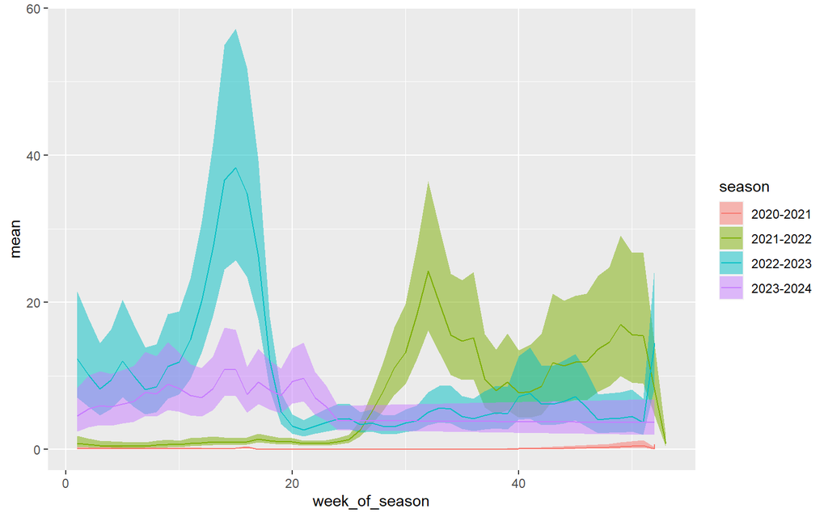

```r
m_week4$summary.random$week_index %>%
  select(week_index=ID,mean,`0.025quant`,`0.975quant`) %>%
  mutate(across(2:4,exp)) %>%
  bind_cols(flu_week_ch2) %>%
  filter(season %in% c("2020-2021","2021-2022","2022-2023","2023-2024")) %>%
  ggplot(aes(x=week_of_season)) +
  geom_ribbon(aes(ymin=`0.025quant`,ymax=`0.975quant`,fill=season),alpha=.5)  +
  geom_line(aes(y=mean,colour=season))
```

Note that there is also the `seasonal` model, but it is somewhat more difficult to handle.

## 1.4 Reporting delays

Let’s now assume that there is a reporting delay: 50% of cases are reported on the same week, 30% in week $t+1$ and 20% in week $t+2$. This data is not available here, but it is a pretty common situation, and we can simulate it. The data should be put in “long” format.

```r
delay_prob = c(.5,.3,.2)
delay_max = 2
flu_week_ch_delay = flu_week_ch2 %>%
  # select(week,year,week_index,value,pop) %>%
  mutate(delay0=rbinom(nrow(flu_week_ch2),size=value,prob=delay_prob[1]),
         delay1=rbinom(nrow(flu_week_ch2),size=value-delay0,prob=delay_prob[2]/(1-delay_prob[1])),
         delay2=value-delay0-delay1) %>%
  gather(key=delay, value=value_delayed,delay0:delay2) %>%
  mutate(delay=parse_number(delay))
```

If we place ourselves at the end of a given week (e.g. February 8th, 2024)

```r
cutoff = 580
flu_week_ch_delay_trim = flu_week_ch_delay %>%
  arrange(week_index,delay) %>%
  mutate(true_value=value,
         true_value_delayed=value_delayed,
         value=ifelse(week_index>cutoff,NA,value),
         value_delayed=ifelse(week_index+delay>cutoff,NA,value_delayed)) %>%
  filter(week_index<=cutoff) %>%
  group_by(week_index) %>%
  mutate(value=sum(value_delayed,na.rm=TRUE)) %>%
  ungroup() %>%
  mutate(week_index2=week_index, delay2=delay+1) # duplicate indexes
flu_week_ch_delay_trim %>%
  select(week,week_index,delay,true_value,true_value_delayed,value,value_delayed) %>%
  tail(10)
```

```
## # A tibble: 10 × 7
##    week       week_index delay true_value true_value_delayed value value_delayed
##    <date>          <dbl> <dbl>      <dbl>              <dbl> <dbl>         <dbl>
##  1 2024-01-18        577     2       1832                390  1832           390
##  2 2024-01-25        578     0       2381               1235  2381          1235
##  3 2024-01-25        578     1       2381                690  2381           690
##  4 2024-01-25        578     2       2381                456  2381           456
##  5 2024-02-01        579     0       2131               1051  1706          1051
##  6 2024-02-01        579     1       2131                655  1706           655
##  7 2024-02-01        579     2       2131                425  1706            NA
##  8 2024-02-08        580     0       1911                940   940           940
##  9 2024-02-08        580     1       1911                579   940            NA
## 10 2024-02-08        580     2       1911                392   940            NA
```

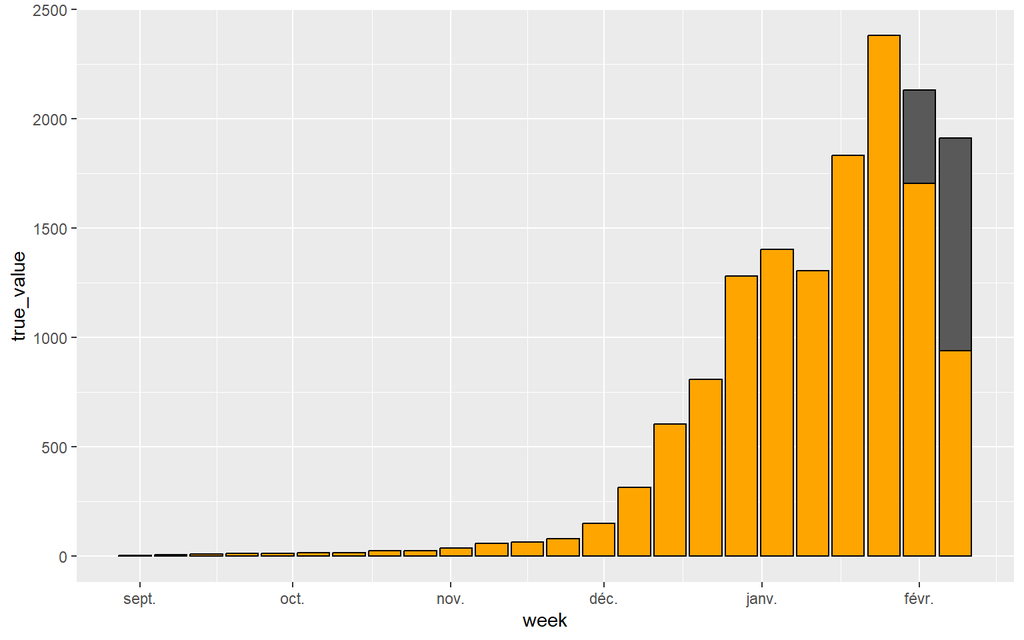

```r
flu_week_ch_delay_trim %>%
  filter(season=="2023-2024",delay==0) %>%
  ggplot(aes(x=week)) +
  geom_col(aes(y=true_value),colour="black") +
  geom_col(aes(y=value),fill="orange",colour="black")
```

We can adjust for the reporting delay following the approach proposed by (Bastos et al. 2019).

```r
m_week5 = inla(value_delayed ~ 1 +
                 f(week_index, model="rw1", hyper=list(prec=list(param=c(1, 0.1))), constr=TRUE) +
                 f(week_of_year, model="rw1", hyper=list(prec=list(param=c(1, 0.1))), constr = TRUE) +
                 f(delay, model="rw1", hyper=list(prec=list(param=c(1, 0.1))), constr = TRUE) +
                 f(week_index2, model="rw1", replicate=delay2, hyper=list(prec=list(param=c(1, 0.1))), constr = TRUE),
               offset = log(pop),
               data = flu_week_ch_delay_trim,
               family = "poisson",
               control.predictor = list(link = 1, compute = TRUE), # option to compute model prediction for NA value
               control.fixed = list(mean.intercept=0, prec.intercept=1/10^2),
               control.compute = list(waic=TRUE))
summary(m_week5)
```

```
##
## Call:
##    c("inla.core(formula = formula, family = family, contrasts = contrasts,
##    ", " data = data, quantiles = quantiles, E = E, offset = offset, ", "
##    scale = scale, weights = weights, Ntrials = Ntrials, strata = strata,
##    ", " lp.scale = lp.scale, link.covariates = link.covariates, verbose =
##    verbose, ", " lincomb = lincomb, selection = selection, control.compute
##    = control.compute, ", " control.predictor = control.predictor,
##    control.family = control.family, ", " control.inla = control.inla,
##    control.fixed = control.fixed, ", " control.mode = control.mode,
##    control.expert = control.expert, ", " control.hazard = control.hazard,
##    control.lincomb = control.lincomb, ", " control.update =
##    control.update, control.lp.scale = control.lp.scale, ", "
##    control.pardiso = control.pardiso, only.hyperparam = only.hyperparam,
##    ", " inla.call = inla.call, inla.arg = inla.arg, num.threads =
##    num.threads, ", " keep = keep, working.directory = working.directory,
##    silent = silent, ", " inla.mode = inla.mode, safe = FALSE, debug =
##    debug, .parent.frame = .parent.frame)" )
## Time used:
##     Pre = 3.4, Running = 5.3, Post = 1.07, Total = 9.78
## Fixed effects:
##                mean    sd 0.025quant 0.5quant 0.975quant    mode kld
## (Intercept) -14.622 0.031    -14.684  -14.622    -14.561 -14.622   0
##
## Random effects:
##   Name     Model
##     week_index RW1 model
##    week_of_year RW1 model
##    delay RW1 model
##    week_index2 RW1 model
##
## Model hyperparameters:
##                              mean     sd 0.025quant 0.5quant 0.975quant   mode
## Precision for week_index     9.62  0.975       7.82     9.59      11.65   9.53
## Precision for week_of_year   8.89  1.990       5.46     8.73      13.24   8.48
## Precision for delay          6.79  5.168       1.10     5.43      20.28   3.05
## Precision for week_index2  351.91 48.286     266.88   348.50     456.63 341.50
##
## Watanabe-Akaike information criterion (WAIC) ...: 7490.91
## Effective number of parameters .................: 312.21
##
## Marginal log-Likelihood:  -4242.62
##  is computed
## Posterior summaries for the linear predictor and the fitted values are computed
## (Posterior marginals needs also 'control.compute=list(return.marginals.predictor=TRUE)')
```

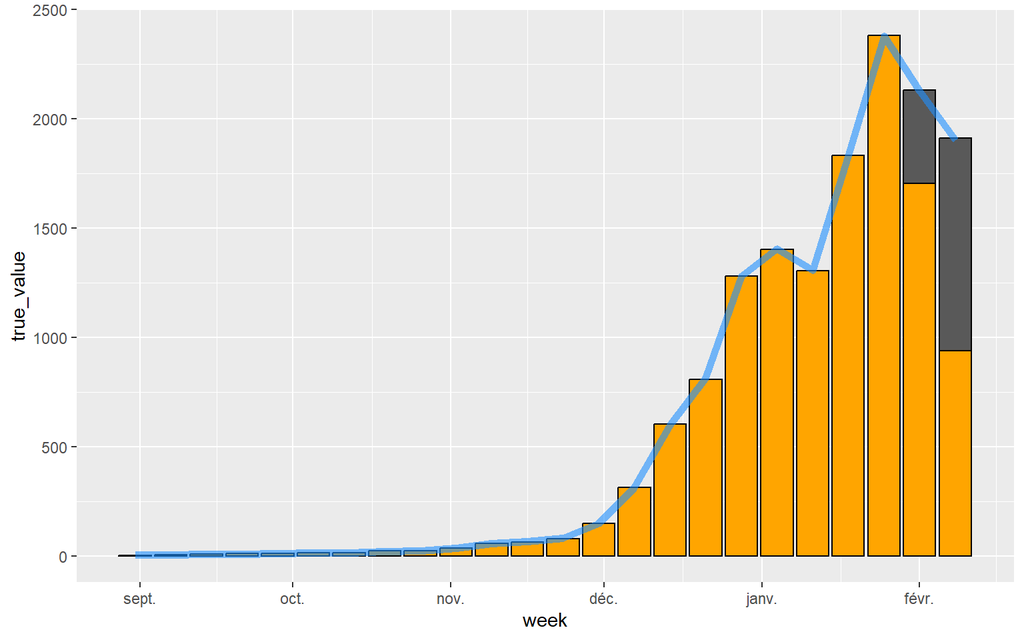

```r
m_week5$summary.fitted.values %>%
  bind_cols(flu_week_ch_delay_trim) %>%
  filter(season=="2023-2024") %>%
  group_by(week) %>%
  summarise(value=max(value),
            true_value=max(true_value),
            pred_value=sum(mean)) %>%
  ggplot(aes(x=week)) +
  geom_col(aes(y=true_value),colour="black") +
  geom_col(aes(y=value),fill="orange",colour="black") +
  geom_line(aes(y=pred_value),colour="dodgerblue",size=2,alpha=.6)
```

The model prediction closely matches the unobserved true value. It is possible to obtain the uncertainty intervals by sampling from the posterior of `value_delayed` with function `inla.posterior.sample()`, and summing the samples by week.

## 1.5 Exercice

Try the approach by (Bastos et al. 2019) for longer reporting delays, e.g. 5 or 7 weeks, and use `inla.posterior.sample()` to compute the uncertainty around the corrected value.

# References

Bastos, Leonardo S, Theodoros Economou, Marcelo FC Gomes, Daniel AM Villela, Flavio C Coelho, Oswaldo G Cruz, Oliver Stoner, Trevor Bailey, and Claudia T Codeço. 2019. “A Modelling Approach for Correcting Reporting Delays in Disease Surveillance Data.” *Statistics in Medicine* 38 (22): 4363–77.